# Policy Notebook

Nick Eberle

May 7, 2019

# POL345: Public Policy Making Notebook

Spring 2019: Nicholas Eberle

## Kingdon Diagram

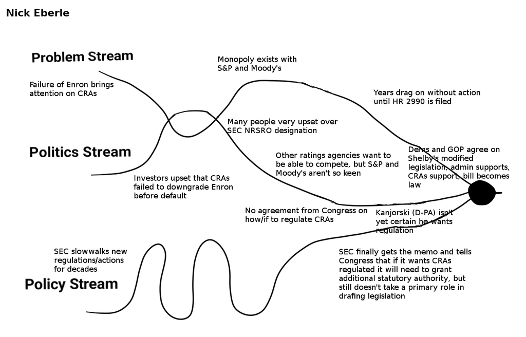

## POL345 Assigned Journal Articles and Book Excerpts

#### Sabatier, Paul A. and Christopher M. Weible. “The Advocacy Coalition Framework: Innovations and Clarifications”. In Theories of the Policy Process. 2007. Boulder: Westrow. [Book Excerpt](https://drive.google.com/open?id=1MVi1vDsJov-jAtnFd9uUGY03BMp1NK6S)

#### Mazmanian, Daniel A. and Paul A. Sabatier. 1983. Implementation of Public Policy. Glenview: Scott, Foresman and Co. [Book Excerpt](https://drive.google.com/open?id=1B8bmH4sarerQYAIfOPlTG9H5AN-o1YkF)

#### Schattschneider, E.E. 1960. The Semi-Sovereign People. New York: Holt, Rinehart & Winston.: [Book Excerpt](https://drive.google.com/open?id=1UWQINx5mtRBBk1RjTv1LCY7IKs76dkCA)

#### Shanahan, Elizabeth, Michael Jones and Mark K. McBeth. 2011. “Policy Narratives and Policy Processes”. Policy Studies Journal. 39-3: 535-61. [Journal Article](https://drive.google.com/open?id=1hK0Wur-ALoHFSD4Q-ekiPimo-dpQa1MY)

#### Andersen, James E. 2006. “Public Policymaking: An Introduction”. New York: Houghton Mifflin.: [Book Excerpt](https://drive.google.com/file/d/1l4Z46qgJSsSnNglDwk00O5Ole4QfI3oc/view?usp=sharing)

#### Jones, Charles O. 1984. An Introduction to the Study of Public Policy. Monetrey: Brooks/Cole.: [Book Excerpt](https://drive.google.com/file/d/1Onbke-x4ICHQkoMFC8P0AqlVbN2Zak4b/view?usp=sharing)

#### Smith, Kevin B. and Christopher W. Larimer. 2009. The Public Policy Primer. Boulder: Westview Press.: [Book Excerpt](https://drive.google.com/file/d/1AacVjaLkJpZN4tGeFF-wR-QBHog6ovtO/view?usp=sharing)

#### Dye, Thomas R. and Hamon Ziegler. 2000. The Irony of Democracy: An Uncommon Introduction to American Politics. Ft. Worth: Harcourt Brace.: [Book Excerpt](https://drive.google.com/file/d/1Bjvwkuqpc-vP0HCAp31oicJwggweInfN/view?usp=sharing)

#### Truman, David B. 1951. The Governmental Process: Political Interests and Public Opinion. New York: Knopf.: [Book Excerpt](https://drive.google.com/open?id=1FZU0HjtGdFY8E77m4EnazL9qDS2N9gcs)

#### Latham, Earl. 1952. “The Group Basis of Politics: Notes for Theory”. American Political Science Review. 46-2: 376-97.: [Journal Article](https://drive.google.com/open?id=1CTSLogwtyK--pQvJtPo46ZeQA_HF6YF7)

#### Bachrach, Peter and Morton S. Baratz. 1962. “the Faces of Power”. American Political Science Review. 56-4: 947-52.: [Journal Article](https://drive.google.com/open?id=1rLJZaBc3d2WBk4SDYTwNQYBJoFt3VqXa)

#### Olson, Mancur. 1971. “Collective Action: The Logic”. in Classic Readings in American Politics. ed Pietro S. Nivala and Ravid A. Rosenbloom. 1986. New York: St. Martin’s Press: [Book Excerpt](https://drive.google.com/open?id=1coJZwFdUp6Tibubdpxwl_0zQCrpJbk3Q)

#### Miliband, Ralph. 1968. “Imperfect Competition”. in Public Policy: The Essential Readings. ed Stella Z. Theodoulou and Matthew A Cohn. 1995. Englewood Cliffs: Prentice Hall.: [Book Excerpt](https://drive.google.com/open?id=1Aw7qwVQ_BB9eehzHaEV5w_gn-Z5wKOqI)

#### Heclo, Hugh. 1978. “Issue Networks and the Executive Establishment”. in Public Policy: The Essential Readings. ed Stella Z. Theodoulou and Matthew A Cohn. 1995. Englewood Cliffs: Prentice Hall.: [Book Excerpt](https://drive.google.com/open?id=11g9viig_tRiFKn7osGw83sKaXX3o8Vnk)

#### Meier, Kenneth K/ 1985. “Regulation: Politics, Bureaucracy and Economics.” in Public Policy: The Essential Readings. ed Stella Z. Theodoulou and Matthew A Cohn. 1995. Englewood Cliffs: Prentice Hall.: [Book Excerpt](https://drive.google.com/open?id=1q_fqovQ_pPcBfRUYWbkQr_LFTKWIO0fP)

#### Lowi, Theodore. 1967. “The Public Philosophy: Interest Group Liberalism”. American Political Science Review. (Mar.) 61-1: 5-24. [Journal Article](https://drive.google.com/open?id=12iL5v7-jSf9dI3q-qKTwWjbH2xdaV-U3)

#### Majone, Giodanerico and Aaron Wildavsky. 1995. “Implementation as Evolution”. in Public Policy: The Essential Readings. ed Stella Z. Theodoulou and Matthew A Cohn. 1995. Englewood Cliffs: Prentice Hall.: [Book Excerpt](https://drive.google.com/open?id=1ypxGZTach7Q_R6DJVfmdG8B58u028vrQ)

#### Edwards, George C. III. 1980. Implementinc Public Policy. Washington: Congressional Quarterly Press.: [Book Excerpt](https://drive.google.com/open?id=1XBoYPcvWaGrcQZgMf_BjQZrZbUIiWjIi)

## POL345 Other Readings

#### Kingdon, John W. 2011. Agendas, Alternatives and Public Policies. Harlow: Pearson. [Book]

#### Allison, Graham. Essence of Decision. 1999. Harlow: Pearson. [Book]

#### Mazmanian, Daniel A. and Paul A. Sabatier. 1983. Implementation of Public Policy. Glenview: Scott, Foresman and Co. [Book]

#### Lindblom, Charles. 1959. “The Science of ‘Muddling Through’”. Public Administration Review, 19-2 (Spring): 79-88.: [Journal Article](https://faculty.washington.edu/mccurdy/SciencePolicy/Lindblom%20Muddling%20Through.pdf)